# Exploration

```python
import pandas as pd


Stroke = pd.read_csv("healthcare-dataset-stroke-data.csv")
```

```python
Stroke.head()
```

|  | id | gender | age | hypertension | heart_disease | ever_married | work_type | Residence_type | avg_glucose_level | bmi | smoking_status | stroke |
| --- | --- | --- | --- | --- | --- | --- | --- | --- | --- | --- | --- | --- |
| 0 | 9046 | Male | 67.0 | 0 | 1 | Yes | Private | Urban | 228.69 | 36.6 | formerly smoked | 1 |
| 1 | 51676 | Female | 61.0 | 0 | 0 | Yes | Self-employed | Rural | 202.21 | NaN | never smoked | 1 |
| 2 | 31112 | Male | 80.0 | 0 | 1 | Yes | Private | Rural | 105.92 | 32.5 | never smoked | 1 |
| 3 | 60182 | Female | 49.0 | 0 | 0 | Yes | Private | Urban | 171.23 | 34.4 | smokes | 1 |
| 4 | 1665 | Female | 79.0 | 1 | 0 | Yes | Self-employed | Rural | 174.12 | 24.0 | never smoked | 1 |

```python
#libraries
import numpy as np
import matplotlib.pyplot as plt
import seaborn as sns
from sklearn.model_selection import train_test_split
```

```python
# keeping data pure
data = Stroke.copy()
print(f'Shape: {data.shape}')
print(data.info())
```

```
Shape: (5110, 12)
<class 'pandas.core.frame.DataFrame'>
RangeIndex: 5110 entries, 0 to 5109
Data columns (total 12 columns):
 #   Column             Non-Null Count  Dtype
---  ------             --------------  -----
 0   id                 5110 non-null   int64
 1   gender             5110 non-null   object
 2   age                5110 non-null   float64
 3   hypertension       5110 non-null   int64
 4   heart_disease      5110 non-null   int64
 5   ever_married       5110 non-null   object
 6   work_type          5110 non-null   object
 7   Residence_type     5110 non-null   object
 8   avg_glucose_level  5110 non-null   float64
 9   bmi                4909 non-null   float64
 10  smoking_status     5110 non-null   object
 11  stroke             5110 non-null   int64
dtypes: float64(3), int64(4), object(5)
memory usage: 479.2+ KB
None
```

- Note: we should changed ever_married to a 1-0 binary.

```python
print(f'Duplicates: {data.duplicated().sum()}\n')
print(f'NaN values:\n\
    id: {data["id"].isna().sum()}\n\
    age: {data["age"].isna().sum()}\n\
    hypertension: {data["hypertension"].isna().sum()}\n\
    heart disease: {data["heart_disease"].isna().sum()}\n\
    glucose: {data["avg_glucose_level"].isna().sum()}\n\
    bmi: {data["bmi"].isna().sum()}\n\
    stroke: {data["stroke"].isna().sum()}\n')
print(f'Number of people with missing bmi that had a stroke: {data[data["bmi"].isna()]["stroke"].sum()} out of 201')
print(f'Total number of people with stroke: {data["stroke"].sum()} out of 5110')
```

```
Duplicates: 0

NaN values:
    id: 0
    age: 0
    hypertension: 0
    heart disease: 0
    glucose: 0
    bmi: 201
    stroke: 0

Number of people with missing bmi that had a stroke: 40 out of 201
Total number of people with stroke: 249 out of 5110
```

The dataset is small, so I'd like to impute these values. (first we create a column to hold whether is being imputed)

- KNN
- Mean (with regard to age/gender)
- Median (with regard to age/gender)

```python
# creating a column to hold boolean for NaN values in BMI
data[["bmi_imputed"]]=0
data.loc[data["bmi"].isna(), "bmi_imputed"]=1
print(f'total number of columns being imputed in the bmi column: {data["bmi_imputed"].sum()}\n')
data.head()
```

```
total number of columns being imputed in the bmi column: 201
```

|  | id | gender | age | hypertension | heart_disease | ever_married | work_type | Residence_type | avg_glucose_level | bmi | smoking_status | stroke | bmi_imputed |
| --- | --- | --- | --- | --- | --- | --- | --- | --- | --- | --- | --- | --- | --- |
| 0 | 9046 | Male | 67.0 | 0 | 1 | Yes | Private | Urban | 228.69 | 36.6 | formerly smoked | 1 | 0 |
| 1 | 51676 | Female | 61.0 | 0 | 0 | Yes | Self-employed | Rural | 202.21 | NaN | never smoked | 1 | 1 |
| 2 | 31112 | Male | 80.0 | 0 | 1 | Yes | Private | Rural | 105.92 | 32.5 | never smoked | 1 | 0 |
| 3 | 60182 | Female | 49.0 | 0 | 0 | Yes | Private | Urban | 171.23 | 34.4 | smokes | 1 | 0 |
| 4 | 1665 | Female | 79.0 | 1 | 0 | Yes | Self-employed | Rural | 174.12 | 24.0 | never smoked | 1 | 0 |

```python
# change ever_married from string to an integer boolean value.
M = {"Yes":1, "No":0}
data["ever_married"] = data["ever_married"].map(M)
data.head()
```

|  | id | gender | age | hypertension | heart_disease | ever_married | work_type | Residence_type | avg_glucose_level | bmi | smoking_status | stroke | bmi_imputed |
| --- | --- | --- | --- | --- | --- | --- | --- | --- | --- | --- | --- | --- | --- |
| 0 | 9046 | Male | 67.0 | 0 | 1 | 1 | Private | Urban | 228.69 | 36.6 | formerly smoked | 1 | 0 |
| 1 | 51676 | Female | 61.0 | 0 | 0 | 1 | Self-employed | Rural | 202.21 | NaN | never smoked | 1 | 1 |
| 2 | 31112 | Male | 80.0 | 0 | 1 | 1 | Private | Rural | 105.92 | 32.5 | never smoked | 1 | 0 |
| 3 | 60182 | Female | 49.0 | 0 | 0 | 1 | Private | Urban | 171.23 | 34.4 | smokes | 1 | 0 |
| 4 | 1665 | Female | 79.0 | 1 | 0 | 1 | Self-employed | Rural | 174.12 | 24.0 | never smoked | 1 | 0 |

```python
# Impute NaN values in bmi with mean after filtering age and gender.
imp_mean_data = data.copy()
frame = data[data["bmi"].isna()][["id","gender","age"]]
for i in frame.index:
    gender = frame["gender"][i]
    age = frame["age"][i]
    ID = frame["id"][i]
    imp_mean_data["bmi"][i] = round(data[(~data["bmi"].isna()) & (data["gender"]==gender) & (data["age"]==age)]["bmi"].mean(),1)

# check if there are still na values
imp_mean_data[imp_mean_data["bmi"].isna()].head()
```

|  | id | gender | age | hypertension | heart_disease | ever_married | work_type | Residence_type | avg_glucose_level | bmi | smoking_status | stroke | bmi_imputed |
| --- | --- | --- | --- | --- | --- | --- | --- | --- | --- | --- | --- | --- | --- |
| 2030 | 38920 | Male | 0.48 | 0 | 0 | 0 | children | Urban | 73.02 | NaN | Unknown | 0 | 1 |

```python
# taking care of single na value in bmi in the imp_mean_data.
imp_mean_data["bmi"][2030] = round(data[(~data["bmi"].isna()) & (data["gender"]=="Male") & (data["age"]<1)]["bmi"].mean(),1)
imp_mean_data["bmi"][2030]
```

```
18.4
```

```python
# Impute NaN values in bmi with median after filtering age and gender.
imp_med_data = data.copy()
frame = data[data["bmi"].isna()][["id","gender","age"]]
for i in frame.index:
    gender = frame["gender"][i]
    age = frame["age"][i]
    ID = frame["id"][i]
    imp_med_data["bmi"][i] = round(data[(~data["bmi"].isna()) & (data["gender"]==gender) & (data["age"]==age)]["bmi"].median(),1)

# check if there are still na values
imp_med_data[imp_med_data["bmi"].isna()].head()
```

|  | id | gender | age | hypertension | heart_disease | ever_married | work_type | Residence_type | avg_glucose_level | bmi | smoking_status | stroke | bmi_imputed |
| --- | --- | --- | --- | --- | --- | --- | --- | --- | --- | --- | --- | --- | --- |
| 2030 | 38920 | Male | 0.48 | 0 | 0 | 0 | children | Urban | 73.02 | NaN | Unknown | 0 | 1 |

```python
# taking care of single na value in bmi in the imp_med_data.

imp_med_data["bmi"][2030] = round(data[(~data["bmi"].isna()) & (data["gender"]=="Male") & (data["age"]<1)]["bmi"].median(),1)
imp_med_data["bmi"][2030]
```

```
17.8
```

```python
# Models:
# KNN
# Logistic Regression
# SVM
# Decision tree
# random forest
```

# Univariate Analysis

```python
print(f' number of unique id values: {data["id"].nunique()}\n')
imp_mean_data.describe(include = "all").T
```

```
 number of unique id values: 5110
```

|  | count | unique | top | freq | mean | std | min | 25% | 50% | 75% | max |
| --- | --- | --- | --- | --- | --- | --- | --- | --- | --- | --- | --- |
| id | 5110.0 | NaN | NaN | NaN | 36517.829354 | 21161.721625 | 67.0 | 17741.25 | 36932.0 | 54682.0 | 72940.0 |
| gender | 5110 | 3 | Female | 2994 | NaN | NaN | NaN | NaN | NaN | NaN | NaN |
| age | 5110.0 | NaN | NaN | NaN | 43.226614 | 22.612647 | 0.08 | 25.0 | 45.0 | 61.0 | 82.0 |
| hypertension | 5110.0 | NaN | NaN | NaN | 0.097456 | 0.296607 | 0.0 | 0.0 | 0.0 | 0.0 | 1.0 |
| heart_disease | 5110.0 | NaN | NaN | NaN | 0.054012 | 0.226063 | 0.0 | 0.0 | 0.0 | 0.0 | 1.0 |
| ever_married | 5110.0 | NaN | NaN | NaN | 0.656164 | 0.475034 | 0.0 | 0.0 | 1.0 | 1.0 | 1.0 |
| work_type | 5110 | 5 | Private | 2925 | NaN | NaN | NaN | NaN | NaN | NaN | NaN |
| Residence_type | 5110 | 2 | Urban | 2596 | NaN | NaN | NaN | NaN | NaN | NaN | NaN |
| avg_glucose_level | 5110.0 | NaN | NaN | NaN | 106.147677 | 45.28356 | 55.12 | 77.245 | 91.885 | 114.09 | 271.74 |
| bmi | 5110.0 | NaN | NaN | NaN | 28.919276 | 7.730565 | 10.3 | 23.7 | 28.3 | 32.9 | 97.6 |
| smoking_status | 5110 | 4 | never smoked | 1892 | NaN | NaN | NaN | NaN | NaN | NaN | NaN |
| stroke | 5110.0 | NaN | NaN | NaN | 0.048728 | 0.21532 | 0.0 | 0.0 | 0.0 | 0.0 | 1.0 |
| bmi_imputed | 5110.0 | NaN | NaN | NaN | 0.039335 | 0.194409 | 0.0 | 0.0 | 0.0 | 0.0 | 1.0 |

- Not sure if we should included children less than a year old.
- More often then not people are in private industy, which makes sense with the population.

```python
# dropping id column for each dataset
imp_mean_data.drop(["id"], axis = 1, inplace = True)
imp_med_data.drop(["id"], axis = 1, inplace = True)
#imp_knn_data.drop(["id"], axis = 1, inplace = True)
```

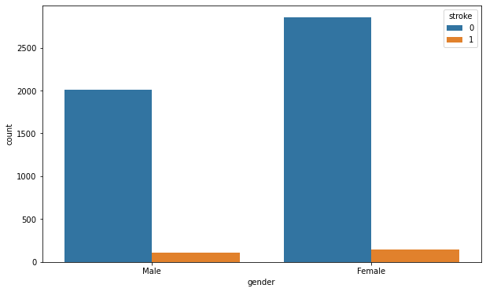

```python
# look at distribution for gender excluding the single "other"

plt.figure(figsize = (10,6))
sns.countplot(x = "gender", data = data[data["gender"]!= "Other"], hue = "stroke")
```

- More females in the study than males by a significant margin

```
age
Skew: -0.14
```

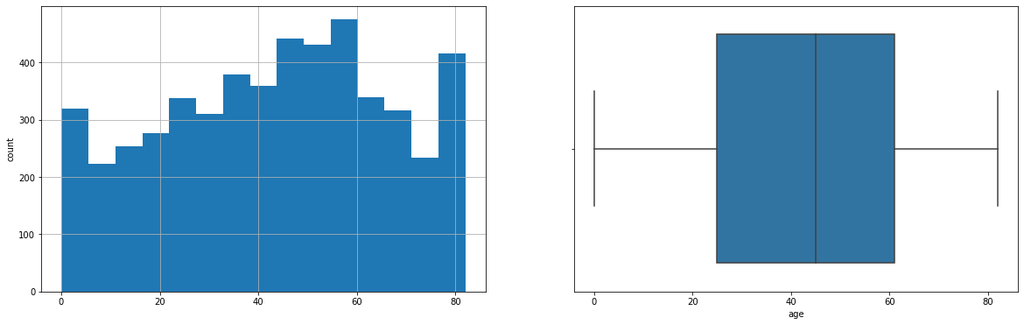

```
avg_glucose_level
Skew: 1.57
```

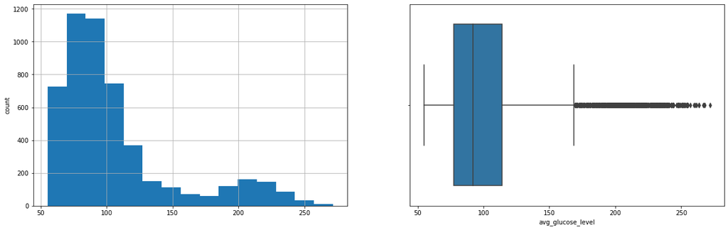

```
bmi
Skew: 1.05
```

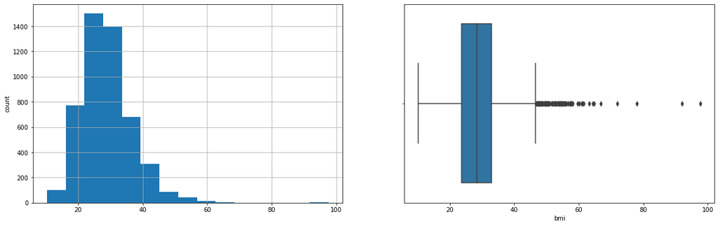

```python
for col in ['age', 'avg_glucose_level', 'bmi']:
    print(col)
    print(f'Skew: {round(imp_mean_data[col].skew(),2)}')
    plt.figure(figsize = (20,6))
    plt.subplot(1,2,1)
    data[col].hist(bins = 15)
    plt.ylabel("count")
    plt.subplot(1,2,2)
    sns.boxplot(x = imp_mean_data[col])
    plt.show()
```

- Age doesn't look like a normal curve, but at least it isn't skewed to one side.
- Avg glucose level is heavily skewed right with many outliers. This may be a precurser to a stroke if the stroke victims happen to be in the outlier section of this graph.
- It looks like the bmi is pretty normal, outside of a few outliers.

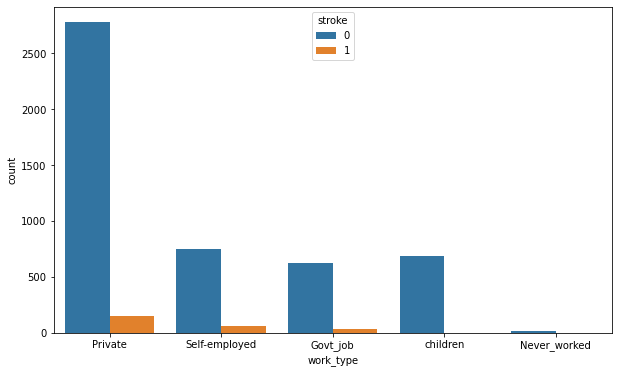

```python
plt.figure(figsize = (10,6))
sns.countplot(data = data, x = "work_type", hue = "stroke")
```

- the numbers look sufficiently scaled to each employment type.

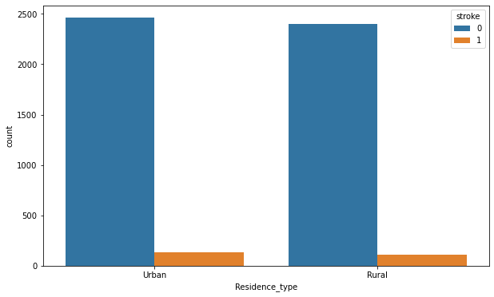

```python
plt.figure(figsize = (10,6))
sns.countplot(data = data, x = "Residence_type", hue = "stroke")
```

- residence doesn't seem to have an obvious effect on stroke susceptibility.

# Bivariate Analysis

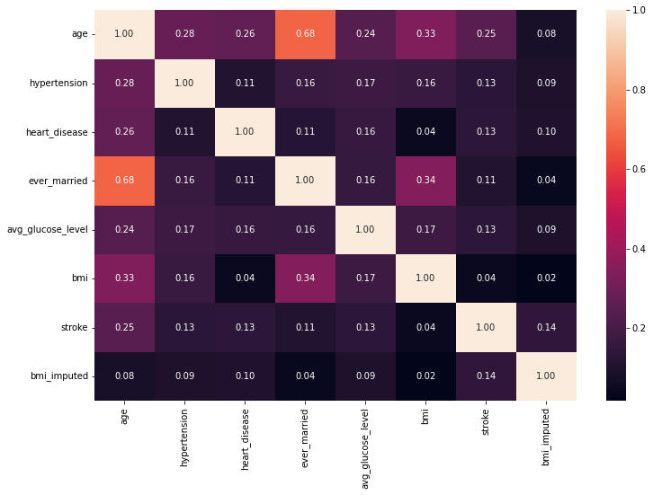

```python
plt.figure(figsize = (12,8))
sns.heatmap(data = imp_mean_data.corr(), annot = True, fmt = '.2f')
plt.show()
```

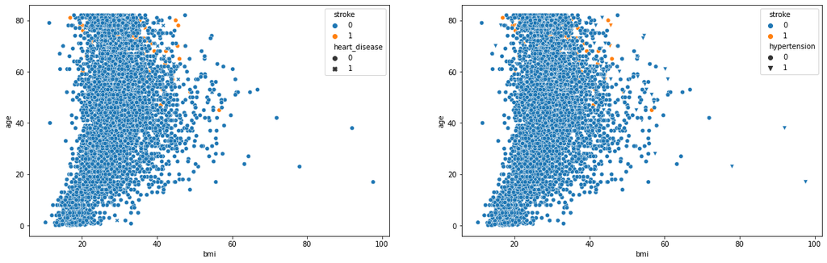

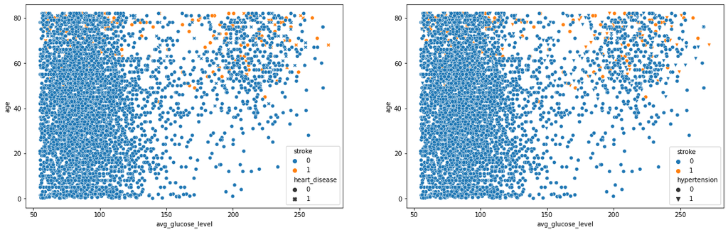

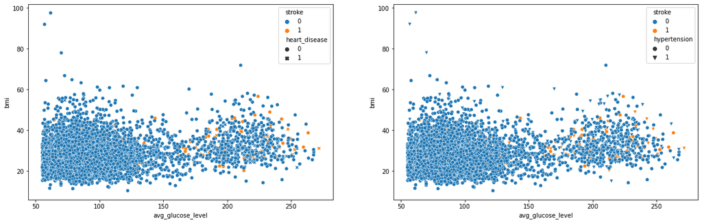

```python
hyp = {0:'o', 1:'v'}

plt.figure(figsize = (20,6))
plt.subplot(1,2,1)
sns.scatterplot(data = imp_mean_data, x = "bmi", y = "age", hue = "stroke", style = "heart_disease")
plt.subplot(1,2,2)
sns.scatterplot(data = imp_mean_data, x = "bmi", y = "age", hue = "stroke", style = "hypertension", markers = hyp)
plt.figure(figsize = (20,6))
plt.subplot(1,2,1)
sns.scatterplot(data = imp_mean_data, x = "avg_glucose_level", y = "age", hue = "stroke", style = "heart_disease")
plt.subplot(1,2,2)
sns.scatterplot(data = imp_mean_data, x = "avg_glucose_level", y = "age", hue = "stroke", style = "hypertension", markers = hyp)
plt.figure(figsize = (20,6))
plt.subplot(1,2,1)
sns.scatterplot(data = imp_mean_data, x = "avg_glucose_level", y = "bmi", hue = "stroke", style = "heart_disease")
plt.subplot(1,2,2)
sns.scatterplot(data = imp_mean_data, x = "avg_glucose_level", y = "bmi", hue = "stroke", style = "hypertension", markers = hyp)
```

- Here we are looking at any correlations between two variables and strokes.
- It still looks like age is really the most reliable estimator.
- It looks like heart disease and strokes are more prevalent in people with higher age and glucose.
- it seems that the strongest correlation with whether or not you had a stroke is age. This makes sense to a degree; more stroke victims tend to be older.
- all other categories outside of bmi seem to be relatively equal when we look at their correlations with whether they had a stroke.
- The most obvious correlation is the age and whether or not they have been married.
- It seems there is truth to the claim that once you land a spouse, you can let yourself go....the correlation is .34 XD
- Age seems to have the strongest correlation with each topic. It makes sense since, diseases, stress and weight all increase as you get older.

# Model Prep

```python
#mean impute
X_mean = imp_mean_data.drop(columns = "stroke")
Y = imp_mean_data["stroke"]


# Median impute
X_med = imp_med_data.drop(columns = "stroke")
```

```python
import sklearn
from sklearn.metrics import confusion_matrix, classification_report, recall_score
from sklearn import metrics

# modified code from Data Science Online courses.
def metrics_score(actual, predicted):
    print(classification_report(actual, predicted))

    cm = confusion_matrix(actual, predicted)
    plt.figure(figsize = (8,5))
    sns.heatmap(cm, annot = True, fmt = '.2f', xticklabels = ['No Stroke', 'Stroke'], yticklabels = ['No Stroke', 'Stroke'])
    plt.ylabel('Actual')
    plt.xlabel('Predicted')
    plt.show()
```

## Mean Impute

```python
X_mean = pd.get_dummies(X_mean, drop_first = True)
#split data to model
X_train, X_test, y_train, y_test = train_test_split(X_mean, Y, test_size = .3, random_state = 1)
```

```python
print(f'Percent of each class in training set: \n{y_train.value_counts(normalize = True)}\n')
print(f'Percent of each class in test set: \n{y_test.value_counts(normalize = True)}')
```

```
Percent of each class in training set:
0    0.953592
1    0.046408
Name: stroke, dtype: float64

Percent of each class in test set:
0    0.945858
1    0.054142
Name: stroke, dtype: float64
```

Note: I want to reduce false negatives as much as possible, so I want to maximize recall.

### Decision Tree

```python
from sklearn.tree import DecisionTreeClassifier
from sklearn import tree
from sklearn.ensemble import RandomForestClassifier
```

```python
Dtree = DecisionTreeClassifier()
Dtree.fit(X_train, y_train)
```

```
DecisionTreeClassifier()
```

```
              precision    recall  f1-score   support

           0       1.00      1.00      1.00      3411
           1       1.00      1.00      1.00       166

    accuracy                           1.00      3577
   macro avg       1.00      1.00      1.00      3577
weighted avg       1.00      1.00      1.00      3577
```

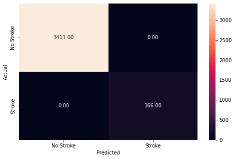

```python
# Making sure model is working.
y_pred_train = Dtree.predict(X_train)
metrics_score(y_train, y_pred_train)
```

```
              precision    recall  f1-score   support

           0       0.95      0.96      0.96      1450
           1       0.20      0.17      0.18        83

    accuracy                           0.92      1533
   macro avg       0.58      0.57      0.57      1533
weighted avg       0.91      0.92      0.92      1533
```

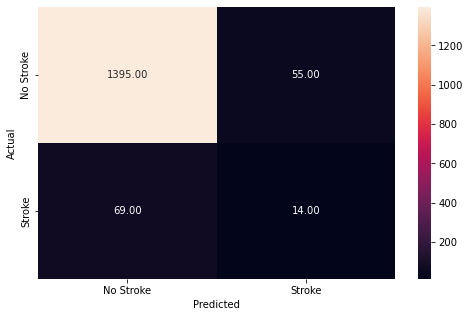

```python
# Check on test data.
y_pred_test = Dtree.predict(X_test)
metrics_score(y_test, y_pred_test)
```

- Clearly overfitted. Note that the accuracy isn't as important as the recall score.

```python
from sklearn.model_selection import GridSearchCV

d_tree_tune = DecisionTreeClassifier(random_state = 1, class_weight = "balanced")

parameters = {'max_depth': np.arange(2,7),
              'criterion':['gini', 'entropy'],
              'min_samples_leaf': [5,10,15]
             }

scorer = metrics.make_scorer(recall_score)
grid_obj = GridSearchCV(d_tree_tune, parameters, scoring = scorer, cv = 5)
grid_obj = grid_obj.fit(X_train, y_train)

d_tree_tuned = grid_obj.best_estimator_

d_tree_tuned.fit(X_train, y_train)
```

```
DecisionTreeClassifier(class_weight='balanced', criterion='entropy',
                       max_depth=2, min_samples_leaf=5, random_state=1)
```

```
              precision    recall  f1-score   support

           0       1.00      0.51      0.68      3411
           1       0.09      0.96      0.16       166

    accuracy                           0.53      3577
   macro avg       0.54      0.74      0.42      3577
weighted avg       0.95      0.53      0.65      3577
```

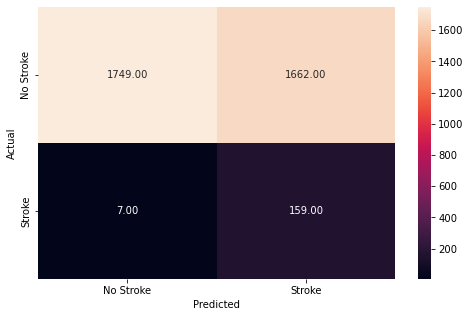

```python
# We check to see how it does on the training set.
y_pred_train = d_tree_tuned.predict(X_train)
metrics_score(y_train, y_pred_train)
```

- Though we predict stroke incorrectly much more often the model only misses 7 people that had a stroke when it predicted they wouldn't
- We correctly predict 96% of the stroke victims.

```
              precision    recall  f1-score   support

           0       1.00      0.53      0.70      1450
           1       0.11      0.96      0.19        83

    accuracy                           0.56      1533
   macro avg       0.55      0.75      0.44      1533
weighted avg       0.95      0.56      0.67      1533
```

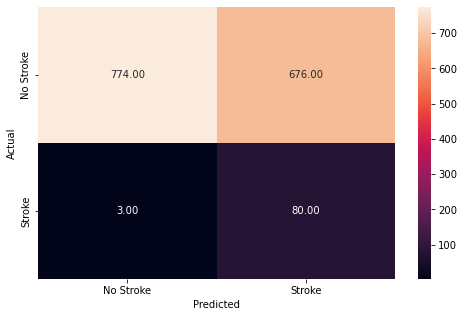

```python
# we now check the test set.
y_pred_test = d_tree_tuned.predict(X_test)
metrics_score(y_test, y_pred_test)
```

- Predictions on the test set are still at 96% recall score.

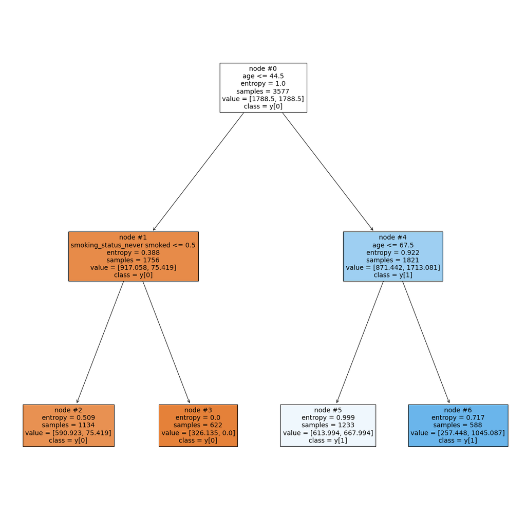

```python
feat = list(X_mean.columns)

plt.figure(figsize=(20,20))
tree.plot_tree(d_tree_tuned, feature_names = feat, filled = True, node_ids = True, class_names = True)
plt.show()
```

- Age seems to be the biggest precurser. Over 67.5 seems to be much higher risk.

```python
print (pd.DataFrame(d_tree_tuned.feature_importances_, columns = ["Importance"], index = X_train.columns).sort_values(by = 'Importance', ascending = False))
```

```
                                Importance
age                               0.955514
smoking_status_never smoked       0.044486
work_type_Never_worked            0.000000
smoking_status_formerly smoked    0.000000
Residence_type_Urban              0.000000
work_type_children                0.000000
work_type_Self-employed           0.000000
work_type_Private                 0.000000
gender_Other                      0.000000
hypertension                      0.000000
gender_Male                       0.000000
bmi_imputed                       0.000000
bmi                               0.000000
avg_glucose_level                 0.000000
ever_married                      0.000000
heart_disease                     0.000000
smoking_status_smokes             0.000000
```

- As we've seen Age is the most important facter in predicting a stroke.

### Random Forest

```python
rf = RandomForestClassifier(class_weight = "balanced")
rf.fit(X_train, y_train)
```

```
RandomForestClassifier(class_weight='balanced')
```

```
              precision    recall  f1-score   support

           0       1.00      1.00      1.00      3411
           1       1.00      0.99      1.00       166

    accuracy                           1.00      3577
   macro avg       1.00      1.00      1.00      3577
weighted avg       1.00      1.00      1.00      3577
```

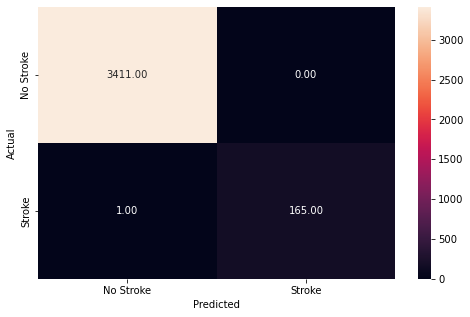

```python
# Check to see if it runs correctly.
y_pred_train = rf.predict(X_train)
metrics_score(y_train, y_pred_train)
```

- Random Forest seems to running ok. Certainly overfit.

```
              precision    recall  f1-score   support

           0       0.95      1.00      0.97      1450
           1       0.20      0.01      0.02        83

    accuracy                           0.94      1533
   macro avg       0.57      0.50      0.50      1533
weighted avg       0.91      0.94      0.92      1533
```

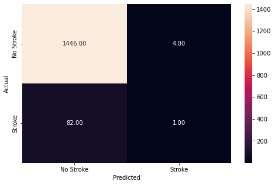

```python
# see how the model does on the test set
y_pred_test = rf.predict(X_test)
metrics_score(y_test, y_pred_test)
```

```python
rf_tuned = RandomForestClassifier(criterion = "entropy", random_state = 1, class_weight = "balanced")
parameters = {"n_estimators":[50,100,120],
              "max_depth":[4,5,6,7],
              "max_features":[.8,.9,1]}

# Using recall as the metric
scorer = metrics.make_scorer(recall_score)

grid = GridSearchCV(rf_tuned, parameters, scoring = scorer, cv = 5)

grid = grid.fit(X_train, y_train)
rf_tuned = grid.best_estimator_
```

```python
#fit tuned model to the training data.
rf_tuned.fit(X_train, y_train)
```

```
RandomForestClassifier(class_weight='balanced', criterion='entropy',
                       max_depth=4, max_features=0.9, n_estimators=50,
                       random_state=1)
```

```
              precision    recall  f1-score   support

           0       0.99      0.78      0.87      3411
           1       0.15      0.81      0.25       166

    accuracy                           0.78      3577
   macro avg       0.57      0.79      0.56      3577
weighted avg       0.95      0.78      0.84      3577
```

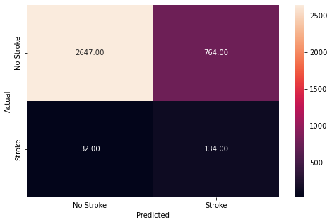

```python
# check to make sure forest runs correctly.
y_pred_train = rf_tuned.predict(X_train)
metrics_score(y_train, y_pred_train)
```

- 81% isn't as good as we got with the decision tree, but it seems to be running correctly.

```
              precision    recall  f1-score   support

           0       0.99      0.77      0.87      1450
           1       0.17      0.80      0.28        83

    accuracy                           0.78      1533
   macro avg       0.58      0.78      0.57      1533
weighted avg       0.94      0.78      0.84      1533
```

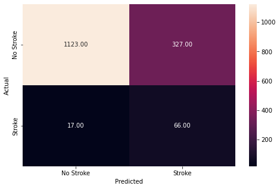

```python
# see how it does on the test set. Expectation is around 80%
y_pred_test = rf_tuned.predict(X_test)
metrics_score(y_test, y_pred_test)
```

- random forest didn't do as well as the decision tree.
- Scored an 80%

```python
print (pd.DataFrame(rf_tuned.feature_importances_, columns = ["Importance"], index = X_train.columns).sort_values(by = 'Importance', ascending = False))
```

```
                                  Importance
age                             7.124716e-01
avg_glucose_level               1.102513e-01
bmi                             6.103167e-02
bmi_imputed                     5.878838e-02
gender_Male                     1.223222e-02
ever_married                    1.055129e-02
work_type_Self-employed         7.969636e-03
smoking_status_smokes           5.290767e-03
hypertension                    5.232878e-03
smoking_status_never smoked     4.578307e-03
heart_disease                   4.011975e-03
work_type_children              3.290525e-03
work_type_Private               2.469229e-03
smoking_status_formerly smoked  1.348659e-03
Residence_type_Urban            4.815711e-04
work_type_Never_worked          5.223330e-17
gender_Other                    0.000000e+00
```

- Age is still the highest precursor to having a stroke.
- Glucose, and Bmi are second and third.

```python
# I want to look at rows where the bmi was imputed.
data[data["bmi_imputed"]==1]["stroke"].value_counts()
```

```
0    161
1     40
Name: stroke, dtype: int64
```

- I noted this before, but I am noting it again because it came up in the previous model. Notice 20% of the data points with no bmi listed had a stroke. We compare that to the rest of the data, where the number of people that had a stroke is closer to 5%. There is a huge discrepancy in these two numbers. This is the reason bmi_imputed is listed as fourth most important feature.

### KNN model

```python
from sklearn.preprocessing import StandardScaler
from sklearn.neighbors import KNeighborsClassifier
# split the data
X_train, X_test, y_train, y_test = train_test_split(X_mean, Y, test_size = .3, random_state = 1)
```

- The KNN model willl only be done with the bmi data being imputed with mean.
- This model doesn't seem like it will work well considering how broadly strokes happen.
- I want to try it anyway to see if it can predict well.

```python
print(f'Percent of each class in training set: \n{y_train.value_counts(normalize = True)}\n')
print(f'Percent of each class in test set: \n{y_test.value_counts(normalize = True)}')
```

```
Percent of each class in training set:
0    0.953592
1    0.046408
Name: stroke, dtype: float64

Percent of each class in test set:
0    0.945858
1    0.054142
Name: stroke, dtype: float64
```

```python
# Normalize each feature.
sc = StandardScaler()
X_train_normal = sc.fit_transform(X_train)
X_test_normal = sc.fit_transform(X_test)
```

```
              precision    recall  f1-score   support

           0       0.96      0.82      0.88      3411
           1       0.08      0.31      0.12       166

    accuracy                           0.79      3577
   macro avg       0.52      0.57      0.50      3577
weighted avg       0.92      0.79      0.85      3577
```

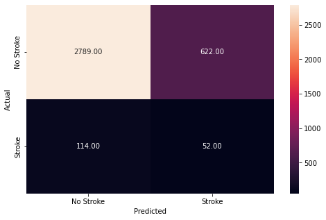

```python
knn = KNeighborsClassifier(weights = "distance", n_neighbors = 3, metric = "euclidean")

knn.fit(X_train_normal, y_train)
y_pred_train = knn.predict(X_train)
metrics_score(y_train, y_pred_train)
```

- This model doesn't do well, but I didn't expect much. As we saw in the bivariate analysis, the points are clumped together with points of the opposite category.

```
              precision    recall  f1-score   support

           0       0.95      0.99      0.97      1450
           1       0.19      0.05      0.08        83

    accuracy                           0.94      1533
   macro avg       0.57      0.52      0.52      1533
weighted avg       0.91      0.94      0.92      1533
```

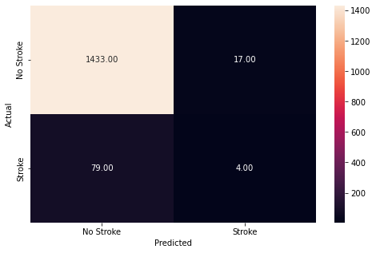

```python
# Running on test set.
y_pred_test = knn.predict(X_test_normal)
metrics_score(y_test, y_pred_test)
```

- as expected, this model performs poorly.

### Support Vector Machine

```python
from sklearn import svm


SVM = svm.SVC(class_weight = 'balanced')
SVM.fit(X_train_normal, y_train)
```

```
SVC(class_weight='balanced')
```

```
              precision    recall  f1-score   support

           0       0.99      0.84      0.91      3411
           1       0.22      0.89      0.35       166

    accuracy                           0.85      3577
   macro avg       0.61      0.86      0.63      3577
weighted avg       0.96      0.85      0.89      3577
```

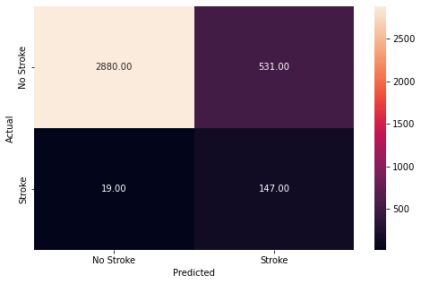

```python
# Checking on training set.
y_pred_train = SVM.predict(X_train_normal)
metrics_score(y_train, y_pred_train)
```

- I adjusted the weights, but the number of misdiagnosed Strokes significantly went up, with not much benefit.

```
              precision    recall  f1-score   support

           0       0.97      0.83      0.89      1450
           1       0.15      0.53      0.23        83

    accuracy                           0.81      1533
   macro avg       0.56      0.68      0.56      1533
weighted avg       0.92      0.81      0.86      1533
```

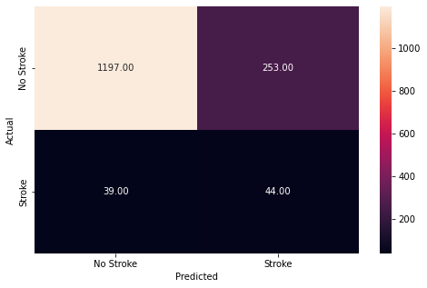

```python
# looking at how the model performs on the test set.
y_pred_test = SVM.predict(X_test_normal)
metrics_score(y_test, y_pred_test)
```

- The model performed well on the training set, but isn't performing on the test set.
- we need to adjust some parameters to prevent overfitting.

```python
SVM_tuned = svm.SVC()
weight = {0:.02, 1:.98}

parameters = {'kernel': ["linear", "poly", "rbf", "sigmoid"],
              'shrinking': [True, False],
              'class_weight':["balanced", weight]
              }
scorer = metrics.make_scorer(recall_score)
grid_obj = GridSearchCV(SVM_tuned, parameters, scoring = scorer, cv = 5)
grid_obj = grid_obj.fit(X_train_normal, y_train)

SVM_tuned = grid_obj.best_estimator_
SVM_tuned.fit(X_train_normal,y_train)
```

```
SVC(class_weight={0: 0.02, 1: 0.98}, kernel='sigmoid')
```

```
              precision    recall  f1-score   support

           0       0.99      0.46      0.63      3411
           1       0.08      0.92      0.14       166

    accuracy                           0.48      3577
   macro avg       0.53      0.69      0.39      3577
weighted avg       0.95      0.48      0.61      3577
```

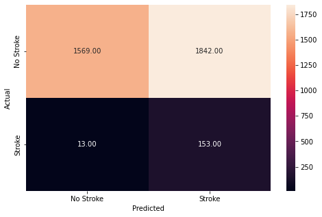

```python
y_pred_train = SVM_tuned.predict(X_train_normal)
metrics_score(y_train, y_pred_train)
```

```
              precision    recall  f1-score   support

           0       1.00      0.56      0.71      1450
           1       0.11      0.96      0.20        83

    accuracy                           0.58      1533
   macro avg       0.55      0.76      0.46      1533
weighted avg       0.95      0.58      0.69      1533
```

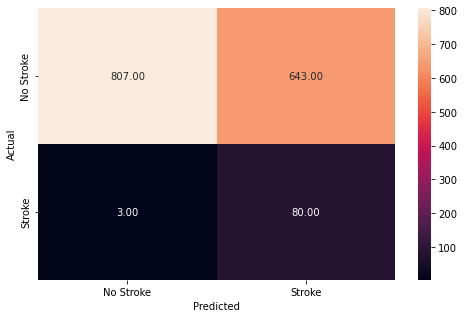

```python
y_pred_test = SVM_tuned.predict(X_test_normal)
metrics_score(y_test, y_pred_test)
```

- Slightly outperforms the decision tree on the test data, but not the training data.
- all in all, I'd say the decision tree still outperforms this model.

## Median Impute

```python
X_med = pd.get_dummies(X_med, drop_first = True)
#split data to model
X_train, X_test, y_train, y_test = train_test_split(X_med, Y, test_size = .3, random_state = 1)
```

```python
print(f'Percent of each class in training set: \n{y_train.value_counts(normalize = True)}\n')
print(f'Percent of each class in test set: \n{y_test.value_counts(normalize = True)}')
```

[output not shown]

### Decision Tree

```python
from sklearn.tree import DecisionTreeClassifier
from sklearn import tree
from sklearn.ensemble import RandomForestClassifier
```

```python
Dtree1 = DecisionTreeClassifier()
Dtree1.fit(X_train, y_train)
```

[output not shown]

```python
# Making sure model is working.
y_pred_train = Dtree1.predict(X_train)
metrics_score(y_train, y_pred_train)
```

[output not shown]

```python
# Check on test data.
y_pred_test = Dtree1.predict(X_test)
metrics_score(y_test, y_pred_test)
```

[output not shown]

```python
from sklearn.model_selection import GridSearchCV

Dtree_tuned = DecisionTreeClassifier(random_state = 1, class_weight = "balanced")

parameters = {'max_depth': np.arange(2,7),
              'criterion':['gini', 'entropy'],
              'min_samples_leaf': [5,10,15]
             }

scorer = metrics.make_scorer(recall_score)
grid_obj = GridSearchCV(d_tree_tune, parameters, scoring = scorer, cv = 5)
grid_obj = grid_obj.fit(X_train, y_train)

Dtree_tuned = grid_obj.best_estimator_

Dtree_tuned.fit(X_train, y_train)
```

[output not shown]

```python
# We check to see how it does on the training set.
y_pred_train = d_tree_tuned.predict(X_train)
metrics_score(y_train, y_pred_train)
```

[output not shown]

- Note that the only difference in the data set is the imputed data for bmi. I would expect this to have identical results as the datset imputed with mean.

```python
# we now check the test set.
y_pred_test = Dtree_tuned.predict(X_test)
metrics_score(y_test, y_pred_test)
```

[output not shown]

```python
feat = list(X_mean.columns)

plt.figure(figsize=(20,20))
tree.plot_tree(Dtree_tuned, feature_names = feat, filled = True, node_ids = True, class_names = True)
plt.show()
```

[output not shown]

```python
print (pd.DataFrame(Dtree_tuned.feature_importances_, columns = ["Importance"], index = X_train.columns).sort_values(by = 'Importance', ascending = False))
```

[output not shown]

### Random Forest

```python
rf1 = RandomForestClassifier(class_weight = "balanced")
rf1.fit(X_train, y_train)
```

[output not shown]

```python
# Check to make sure forest is running correctly
y_pred_train = rf1.predict(X_train)
metrics_score(y_train, y_pred_train)
```

[output not shown]

```python
# see how the model does on the test set
y_pred_test = rf1.predict(X_test)
metrics_score(y_test, y_pred_test)
```

[output not shown]

```python
rf1_tuned = RandomForestClassifier(criterion = "entropy", random_state = 1, class_weight = "balanced")
parameters = {"n_estimators":[50,100,120],
              "max_depth":[4,5,6,7],
              "max_features":[.8,.9,1]}

# Using recall as the metric
scorer = metrics.make_scorer(recall_score)

grid = GridSearchCV(rf1_tuned, parameters, scoring = scorer, cv = 5)

grid = grid.fit(X_train, y_train)
rf1_tuned = grid.best_estimator_
```

```python
#fit tuned model to the training data.
rf1_tuned.fit(X_train, y_train)
```

[output not shown]

```python
# make sure the model runs properly.
y_pred_train = rf1_tuned.predict(X_train)
metrics_score(y_train, y_pred_train)
```

[output not shown]

```python
y_pred_test = rf1_tuned.predict(X_test)
metrics_score(y_test, y_pred_test)
```

[output not shown]

```python
print (pd.DataFrame(rf1_tuned.feature_importances_, columns = ["Importance"], index = X_train.columns).sort_values(by = 'Importance', ascending = False))
```

[output not shown]